# Pre-Screening for Treatment Effect Heterogeneity

- Show All Code
- Hide All Code
- View Source

Crump et al. (2008) Tests: OLS, Logistic, and Poisson+Offset

Author

Larry F. Leon

Published

May 28, 2026

# 1 Introduction

## 1.1 Motivation

Before running `forestsearch()`, a natural first question is: **is there statistical evidence of treatment effect heterogeneity?** Crump, Hotz, Imbens, and Mitnik (2008) developed two nonparametric tests that answer this directly. These tests avoid the multiple-testing problem that arises when estimating average effects for many substantively interesting subpopulations: a single test for zero conditional average treatment effects replaces many individual subgroup tests.

## 1.2 The Two Tests

**Test 1 (Zero CATE, eq. 2.2):** $H_0: \tau(x) = 0$ for all $x \in \mathbb{X}$. Is there ANY subpopulation with a nonzero average treatment effect? This is much stronger than the standard test of $E[\tau(X)] = 0$ (zero ATE), which averages over subpopulations and can miss opposing effects that cancel out.

**Test 2 (Constant CATE, eq. 2.3):** $H_0': \tau(x) = \tau$ for some $\tau$ and all $x \in \mathbb{X}$. Is the average treatment effect the SAME across all subpopulations? This is the key diagnostic for whether subgroup identification is warranted.

**Contrast with the standard ATE test (eq. 2.4):** $H_0'': E[\tau(X)] = 0$. The standard test can fail to reject when there are strong opposing effects that cancel on average. For example, if a treatment doubles the event rate in one subgroup (OR = 2.0) but halves it in another (OR = 0.4), the overall ATE may be near zero — but both Crump tests will detect the heterogeneity.

## 1.3 Statistical Framework

### 1.3.1 Setup

We observe $(Y_i, W_i, X_i)$ for $i = 1, \ldots, N$, where $Y_i$ is the outcome, $W_i \in \{0, 1\}$ is the treatment indicator, and $X_i \in \mathbb{R}^d$ are covariates. Under unconfoundedness (Assumption 2.2), $W \perp (Y(0), Y(1)) | X$, and with overlap (Assumption 2.3), $\eta \le e(x) \le 1 - \eta$ for some $\eta > 0$. In an RCT with 1:1 randomization, both conditions are automatically satisfied.

Define the conditional means $\mu_w(x) = E[Y(w) | X = x]$ for $w = 0, 1$ and the conditional average treatment effect $\tau(x) = \mu_1(x) - \mu_0(x)$.

### 1.3.2 Series (Sieve) Regression

The key idea is to approximate $\mu_w(x)$ using a polynomial basis $P_K(x) = (p_1(x), \ldots, p_K(x))'$. For `poly_order = 1`, this is simply $P_K(x) = (1, x_1, \ldots, x_d)'$ with $K = d + 1$.

Separately for treated ($W = 1$) and control ($W = 0$) groups, fit:
$$\hat\mu_w(x) = P_K(x)'\hat\xi_{w,K}, \quad w = 0, 1$$

**For OLS** (original paper): $\hat\xi_{w,K}$ minimizes $\sum_{i: W_i = w} (Y_i - P_K(X_i)'\xi)^2$.

**For GLM extension**: $\hat\xi_{w,K}$ maximizes the GLM log-likelihood separately in each arm. This is a natural extension when the outcome is non-Gaussian.

The null hypotheses translate to restrictions on the coefficient vectors: $H_0: \tau(x) = 0$ becomes $H_0: \xi_{0,K} = \xi_{1,K}$ (all coefficients equal); $H_0': \tau(x) = \tau$ becomes $H_0': \xi_{0,1,K} = \xi_{1,1,K}$ (slope coefficients equal, intercepts may differ).

### 1.3.3 HC Sandwich Variance

Under general heteroskedasticity, the variance of $\hat\xi_{w,K}$ is estimated by the HC0 sandwich.

**OLS (eq. 3.6):**
$$\hat\Omega_w = N_w \cdot
\left(\sum_{i: W_i=w} P_i P_i'\right)^{-1}
\left(\sum_{i: W_i=w} \hat{e}_i^2 P_i P_i'\right)
\left(\sum_{i: W_i=w} P_i P_i'\right)^{-1}$$
where $P_i = P_K(X_i)$ and $\hat{e}_i = Y_i - P_K(X_i)'\hat\xi_{w,K}$ are the OLS residuals. For binary $Y$, the residual variance at each point is approximately $\hat{p}(x)(1-\hat{p}(x))$, and the sandwich absorbs this automatically without requiring specification of the variance function.

**GLM:**
$$\hat\Omega_w = N_w \cdot A^{-1} B A^{-1}$$
where $A = \sum_{i: W_i=w} w_i P_i P_i'$ is the expected Fisher information with working weights $w_i = (\partial\mu/\partial\eta)_i^2 / \text{Var}(\mu_i)$, and $B = \sum_{i: W_i=w} s_i s_i'$ is the empirical score outer product with score contributions $s_i = P_i \cdot (\partial\mu/\partial\eta)_i \cdot (Y_i - \mu_i) / \text{Var}(\mu_i)$.

For **Poisson** (log link): $w_i = \mu_i$ and $s_i = P_i (Y_i - \mu_i)$.

For **logistic** (logit link): $w_i = \mu_i(1 - \mu_i)$ and $s_i = P_i (Y_i - \mu_i)$.

The combined variance of the coefficient difference is:
$$\hat{V} = \hat\Omega_0 / N_0 + \hat\Omega_1 / N_1$$

### 1.3.4 Test Statistics

**Zero CATE (eq. 3.8):**
$$Q = (\hat\xi_{1,K} - \hat\xi_{0,K})' \hat{V}^{-1}
(\hat\xi_{1,K} - \hat\xi_{0,K})
\xrightarrow{d} \chi^2(K) \quad \text{under } H_0$$

**Constant CATE (eq. 3.10):** Remove the intercept component (which captures the overall ATE) and test only the slope coefficients $\hat\xi_{w,1,K}$ (indices $2:K$):
$$Q' = (\hat\xi_{1,1,K} - \hat\xi_{0,1,K})' \hat{V}_{11}^{-1}
(\hat\xi_{1,1,K} - \hat\xi_{0,1,K})
\xrightarrow{d} \chi^2(K-1) \quad \text{under } H_0'$$

**Normalized version (large $K$):** $T = (Q - K) / \sqrt{2K} \xrightarrow{d} N(0, 1)$.

The $p$-values come from standard $\chi^2$ or normal tables — no bootstrap or simulation is required. The authors recommend one-sided critical values (reject for large $Q$) since the test statistic is a quadratic form that is large when the regression functions differ.

### 1.3.5 Asymptotic Theory

The validity of the nonparametric test requires (Assumptions 3.1–3.3):

- The regression functions $\mu_w(x)$ are $s$ times continuously differentiable with $s/d > 27/4$.
- The number of basis terms $K$ grows with $N$ as $K = C \cdot N^\nu$ for $d/(2s + 2d) < \nu < 2/13$.

In practice (their applications, Tables 2 and 4), fixed $K$ is used with covariate selection. The asymptotic theory ensures that the parametric test remains valid as the model becomes more flexible.

**Consistency (Theorem 3.2):** The test can detect local alternatives $\mu_1(x) - \mu_0(x) = \rho_N \cdot \Delta(x)$ whenever $\rho_N^{-1} = O(N^{1/2 - 2\nu - \varepsilon})$.

### 1.3.6 Covariate Selection

The paper implements three methods (Section IV):

- **All covariates**: Use all $d$ covariates in the basis.
- **Top-down**: Start with all covariates; sequentially drop the covariate with the smallest $|t|$-statistic until all remaining have $|t| \ge 2$. Selection uses control-group data only, then the same specification is applied to the treatment group.
- **Bottom-up**: Start empty; sequentially add the covariate with the highest $|t|$-statistic until no remaining covariate has $|t| \ge 2$.

Results were robust to the selection method across all eight evaluation sites (Tables 2 and 4).

## 1.4 Application to Binary Outcomes

When $Y \in \{0, 1\}$, the OLS approach estimates a **linear probability model (LPM)**: $\hat\mu_w(x) \approx \Pr(Y = 1 | X = x, W = w)$. The LPM can predict outside $[0, 1]$, but this does not invalidate the test — the null hypothesis concerns the conditional mean function, not its range.

The HC sandwich is automatically heteroskedasticity-robust: for binary $Y$, the conditional variance is $\text{Var}(Y | X = x) = p(x)(1 - p(x))$, which varies across observations. The sandwich estimator captures this without requiring the analyst to specify the variance function.

**Scale of the test:** The OLS test targets the **risk difference** scale: $\tau_{\text{RD}}(x) = \Pr(Y=1|X,W=1) - \Pr(Y=1|X,W=0)$. The logistic extension targets the **log-odds** scale: $\tau_{\text{logOR}}(x) = \text{logit}(\mu_1(x)) - \text{logit}(\mu_0(x))$. For the simulation DGM with opposing effects (OR = 2.0 vs OR = 0.4), both scales detect heterogeneity, but power may differ because the signal-to-noise ratio is scale-dependent.

**Power considerations:** The LPM is not the most efficient estimator for binary data. The logistic extension may have slightly higher power because the logit link better matches the DGM. However, the OLS version is simpler and the asymptotic theory is established.

## 1.5 Application to Survival via Poisson + Offset

For survival data analyzed as event counts with follow-up exposure, the Poisson + offset model fits:
$$\log E[Y_i | X_i, W_i = w] = P_K(X_i)'\xi_w + \log(t_i)$$
where $Y_i \in \{0, 1\}$ is the event indicator and $t_i$ is the follow-up time. The offset $\log(t_i)$ accounts for differential exposure, so the coefficients $\xi_w$ estimate **log event rates per unit time**.

This is the same model underlying the **IRR pipeline** in `forestsearch`. The Poisson model with binary $Y$ is an approximation to the Cox proportional hazards model: when event rates are low, $\Pr(\text{event in } [0, t]) \approx \lambda t$, and the Poisson likelihood approximates the partial likelihood.

**Score contributions** for Poisson: $s_i = P_i \cdot (Y_i - \hat\mu_i)$, where $\hat\mu_i = \exp(P_K(X_i)'\hat\xi_w + \log t_i)$. The sandwich variance uses these scores to account for overdispersion relative to the Poisson model.

**Practical note:** The covariates must be passed as a numeric matrix (no R factors) to avoid rank-deficiency when `build_basis()` adds the intercept. Convert factors to 0/1 indicators via `as.numeric(factor) - 1`.

## 1.6 Connection to ForestSearch

The **Constant CATE test** is the natural pre-screening diagnostic for `forestsearch()`:

```
# Recommended workflow
hte <- test_hte(Y, W, X)
if (hte$constant_cate$p_value_chi < 0.05) {
  # HTE exists: proceed with subgroup identification
  fs <- forestsearch(...)
} else {
  # No evidence of HTE: interpret forestsearch results cautiously
}
```

This provides a formal, published justification for running the subgroup search.

**Key distinction:** The “null” in the simulation study means “no HTE” (uniform treatment effect), not “no treatment effect.” Under the continuous H0 DGM ($\tau(x) = -0.5$ for all $x$), the Zero CATE test correctly rejects (there IS a nonzero effect for all subpopulations), but the Constant CATE test correctly does NOT reject (there IS NO heterogeneity). This distinction is important for interpreting the size/power table.

# 2 Setup

```r
library(data.table)
library(ggplot2)
library(patchwork)
library(gt)
library(foreach)
library(doFuture)
library(future)
library(survival)
```

```r
source(here::here("../R", "test_hte_crump.R"))
```

```r
timings <- list()
t_vignette_start <- proc.time()
```

```r
plan(multisession, workers = n_workers)
cat("Using", n_workers, "parallel workers\n")
```

```
#> Using 120 parallel workers
```

```r
cat("Sims per scenario:", nsims, "\n")
```

```
#> Sims per scenario: 500
```

# 3 Data-Generating Mechanisms

```r
sim_binary <- function(n, seed, has_hte = TRUE) {
  set.seed(seed)
  df <- data.frame(
    id    = seq_len(n),
    treat = rbinom(n, 1, 0.5),
    bm1   = as.factor(rbinom(n, 1, 0.70)),
    bm2   = as.factor(rbinom(n, 1, 0.50)),
    bm3   = as.factor(rbinom(n, 1, 0.45)),
    age   = round(rnorm(n, 55, 10)),
    ecog  = as.factor(sample(0:1, n, TRUE, c(0.6, 0.4)))
  )
  lp <- with(df, -0.85 + 0.02 * (age - 55) + 0.3 * (ecog == 1))
  if (has_hte)
    lp <- lp + with(df, 0.69 * treat * (bm1 == 0) +
                         -0.92 * treat * (bm1 == 1))
  df$progressed <- rbinom(n, 1, plogis(lp))
  df
}

sim_continuous <- function(n, seed, has_hte = TRUE) {
  set.seed(seed)
  df <- data.frame(
    id       = seq_len(n),
    treat    = rbinom(n, 1, 0.5),
    sero     = as.factor(rbinom(n, 1, 0.65)),
    male     = as.factor(rbinom(n, 1, 0.40)),
    smoking  = as.factor(rbinom(n, 1, 0.25)),
    age      = round(rnorm(n, 55, 12)),
    bas_das  = round(rnorm(n, 6.0, 0.8), 1)
  )
  mu <- with(df, -1.5 - 0.3 * (bas_das - 6.0))
  if (has_hte) {
    mu <- mu + with(df, 0.5 * treat * (sero == 0) -
                         1.0 * treat * (sero == 1))
  } else {
    mu <- mu - 0.5 * df$treat
  }
  df$das28_chg <- round(mu + rnorm(n, 0, 1.5), 2)
  df
}

sim_count <- function(n, seed, has_hte = TRUE) {
  set.seed(seed)
  df <- data.frame(
    id        = seq_len(n),
    treat     = rbinom(n, 1, 0.5),
    eos_low   = as.factor(rbinom(n, 1, 0.65)),
    smoking   = as.factor(rbinom(n, 1, 0.50)),
    male      = as.factor(rbinom(n, 1, 0.45)),
    age       = round(rnorm(n, 60, 12)),
    follow_up = round(runif(n, 0.5, 3.0), 2)
  )
  log_rate <- with(df, -1.0 + 0.02 * (age - 60) + log(follow_up))
  if (has_hte)
    log_rate <- log_rate + with(df, 1.0 * treat * (eos_low == 0) -
                                     0.5 * treat * (eos_low == 1))
  df$exacerbations <- rpois(n, lambda = exp(log_rate))
  df
}

sim_survival_poisson <- function(n, seed, has_hte = TRUE) {
  set.seed(seed)
  df <- data.frame(
    id        = seq_len(n),
    treat     = rbinom(n, 1, 0.5),
    biomarker = as.factor(rbinom(n, 1, 0.70)),
    stage     = as.factor(rbinom(n, 1, 0.40)),
    age       = round(rnorm(n, 60, 10)),
    smoking   = as.factor(rbinom(n, 1, 0.35))
  )
  log_rate <- with(df, log(0.5) + 0.02 * (age - 60) +
                        0.3 * (stage == 1))
  if (has_hte)
    log_rate <- log_rate + with(df,
      log(2.0) * treat * (biomarker == 0) +
      log(0.6) * treat * (biomarker == 1))
  event_time <- rexp(n, rate = exp(log_rate))
  cens_time <- runif(n, 1.0, 5.0)
  df$follow_up <- pmin(event_time, cens_time)
  df$event <- as.integer(event_time <= cens_time)
  df$log_fu <- log(df$follow_up)
  df
}
```

## 3.1 Covariate Construction

Covariates must be passed as a **numeric matrix** (no factors) to avoid collinearity when `build_basis()` adds its intercept. Convert factors to 0/1 indicators:

```r
make_X_binary <- function(df) {
  cbind(bm1  = as.numeric(df$bm1) - 1,
        bm2  = as.numeric(df$bm2) - 1,
        bm3  = as.numeric(df$bm3) - 1,
        age  = df$age,
        ecog = as.numeric(df$ecog) - 1)
}

make_X_continuous <- function(df) {
  cbind(sero    = as.numeric(df$sero) - 1,
        male    = as.numeric(df$male) - 1,
        smoking = as.numeric(df$smoking) - 1,
        age     = df$age,
        bas_das = df$bas_das)
}

make_X_count <- function(df) {
  cbind(eos_low = as.numeric(df$eos_low) - 1,
        smoking = as.numeric(df$smoking) - 1,
        male    = as.numeric(df$male) - 1,
        age     = df$age)
}

make_X_survival <- function(df) {
  cbind(biomarker = as.numeric(df$biomarker) - 1,
        stage     = as.numeric(df$stage) - 1,
        age       = df$age,
        smoking   = as.numeric(df$smoking) - 1)
}
```

# 4 Single-Dataset Demonstrations

## 4.1 Binary: OLS vs Logistic

```r
df_b <- sim_binary(800, sim_seed + 1, has_hte = TRUE)
X_b <- make_X_binary(df_b)

cat("=== Binary (N=800, H1: OR_H=2.0, OR_Hc=0.4) ===\n\n")
```

```
#> === Binary (N=800, H1: OR_H=2.0, OR_Hc=0.4) ===
```

```r
cat("--- OLS (linear probability model) ---\n")
```

```
#> --- OLS (linear probability model) ---
```

```r
print(test_hte(df_b$progressed, df_b$treat, X_b, regression = "ols"))
```

```
#> === Crump et al. (2008) HTE Tests ===
#>     Covariates: bm1, bm2, bm3, age, ecog
#>
#> 1. Zero Cond. Ave. TE:     chi-sq= 24.47 (df=6) p=0.0004 | z=  5.33 p=0.0000
#> 2. Constant Cond. Ave. TE: chi-sq= 11.23 (df=5) p=0.0470 | z=  1.97 p=0.0244
#> 3. Zero Ave. TE:           chi-sq=  8.82 (df=1) p=0.0030 | z= -2.97 p=0.0030
#>
#> N0=412, N1=388, K=6
```

```r
cat("\n--- Logistic ---\n")
```

```
#>
#> --- Logistic ---
```

```r
print(test_hte(df_b$progressed, df_b$treat, X_b,
               regression = "logistic"))
```

```
#> === Crump et al. (2008) HTE Tests ===
#>     Regression: logistic
#>     Covariates: bm1, bm2, bm3, age, ecog
#>
#> 1. Zero Cond. Ave. TE:     chi-sq= 22.96 (df=6) p=0.0008 | z=  4.89 p=0.0000
#> 2. Constant Cond. Ave. TE: chi-sq= 13.88 (df=5) p=0.0164 | z=  2.81 p=0.0025
#> 3. Zero Ave. TE:           chi-sq=  8.82 (df=1) p=0.0030 | z= -2.97 p=0.0030
#>
#> N0=412, N1=388, K=6
```

## 4.2 Survival via Poisson + Offset

```r
df_s <- sim_survival_poisson(700, sim_seed + 1, has_hte = TRUE)
X_s <- make_X_survival(df_s)

cat("=== Survival via Poisson+offset (N=700, H1) ===\n")
```

```
#> === Survival via Poisson+offset (N=700, H1) ===
```

```r
cat("  IRR(harm): 2.0 | IRR(complement): 0.6\n")
```

```
#>   IRR(harm): 2.0 | IRR(complement): 0.6
```

```r
cat("  Event rate:", round(mean(df_s$event), 3), "\n\n")
```

```
#>   Event rate: 0.749
```

```r
print(test_hte(df_s$event, df_s$treat, X_s,
               regression = "poisson", offset = df_s$log_fu))
```

```
#> === Crump et al. (2008) HTE Tests ===
#>     Regression: poisson
#>     Covariates: biomarker, stage, age, smoking
#>
#> 1. Zero Cond. Ave. TE:     chi-sq= 37.41 (df=5) p=0.0000 | z= 10.25 p=0.0000
#> 2. Constant Cond. Ave. TE: chi-sq= 34.43 (df=4) p=0.0000 | z= 10.76 p=0.0000
#> 3. Zero Ave. TE:           chi-sq=  6.42 (df=1) p=0.0113 | z= -2.53 p=0.0113
#>
#> N0=352, N1=348, K=5
```

## 4.3 Count: OLS vs Poisson + Offset

```r
df_k <- sim_count(1000, sim_seed + 1, has_hte = TRUE)
X_k <- make_X_count(df_k)

cat("=== Count (N=1000, H1: IRR_H=2.7, IRR_Hc=0.61) ===\n\n")
```

```
#> === Count (N=1000, H1: IRR_H=2.7, IRR_Hc=0.61) ===
```

```r
cat("--- OLS ---\n")
```

```
#> --- OLS ---
```

```r
print(test_hte(df_k$exacerbations, df_k$treat, X_k,
               regression = "ols"))
```

```
#> === Crump et al. (2008) HTE Tests ===
#>     Covariates: eos_low, smoking, male, age
#>
#> 1. Zero Cond. Ave. TE:     chi-sq=120.33 (df=5) p=0.0000 | z= 36.47 p=0.0000
#> 2. Constant Cond. Ave. TE: chi-sq=115.61 (df=4) p=0.0000 | z= 39.46 p=0.0000
#> 3. Zero Ave. TE:           chi-sq=  3.00 (df=1) p=0.0835 | z=  1.73 p=0.0835
#>
#> N0=511, N1=489, K=5
```

```r
cat("\n--- Poisson + offset ---\n")
```

```
#>
#> --- Poisson + offset ---
```

```r
print(test_hte(df_k$exacerbations, df_k$treat, X_k,
               regression = "poisson", offset = log(df_k$follow_up)))
```

```
#> === Crump et al. (2008) HTE Tests ===
#>     Regression: poisson
#>     Covariates: eos_low, smoking, male, age
#>
#> 1. Zero Cond. Ave. TE:     chi-sq=135.51 (df=5) p=0.0000 | z= 41.27 p=0.0000
#> 2. Constant Cond. Ave. TE: chi-sq=135.09 (df=4) p=0.0000 | z= 46.35 p=0.0000
#> 3. Zero Ave. TE:           chi-sq=  3.00 (df=1) p=0.0835 | z=  1.73 p=0.0835
#>
#> N0=511, N1=489, K=5
```

# 5 Monte Carlo Evaluation

## 5.1 Design

```r
mc_scenarios <- data.frame(
  id = c("B-H0-ols", "B-H1-ols",
         "B-H0-logit", "B-H1-logit",
         "C-H0", "C-H1",
         "K-H0-ols", "K-H1-ols",
         "K-H0-pois", "K-H1-pois",
         "S-H0-pois", "S-H1-pois"),
  dgm = c(rep("binary", 4), rep("continuous", 2),
           rep("count", 4), rep("survival", 2)),
  has_hte = rep(c(FALSE, TRUE), 6),
  N = c(800, 800, 800, 800, 600, 600,
        1000, 1000, 1000, 1000, 700, 700),
  regression = c("ols", "ols", "logistic", "logistic",
                 "ols", "ols",
                 "ols", "ols", "poisson", "poisson",
                 "poisson", "poisson"),
  use_offset = c(FALSE, FALSE, FALSE, FALSE, FALSE, FALSE,
                 FALSE, FALSE, TRUE, TRUE, TRUE, TRUE),
  stringsAsFactors = FALSE
)

gt(mc_scenarios) |>
  tab_header(
    title = "Monte Carlo Scenarios",
    subtitle = sprintf("%d simulations per scenario", nsims)
  )
```

Monte Carlo Scenarios

500 simulations per scenario

| id | dgm | has_hte | N | regression | use_offset |
| --- | --- | --- | --- | --- | --- |
| B-H0-ols | binary | FALSE | 800 | ols | FALSE |
| B-H1-ols | binary | TRUE | 800 | ols | FALSE |
| B-H0-logit | binary | FALSE | 800 | logistic | FALSE |
| B-H1-logit | binary | TRUE | 800 | logistic | FALSE |
| C-H0 | continuous | FALSE | 600 | ols | FALSE |
| C-H1 | continuous | TRUE | 600 | ols | FALSE |
| K-H0-ols | count | FALSE | 1000 | ols | FALSE |
| K-H1-ols | count | TRUE | 1000 | ols | FALSE |
| K-H0-pois | count | FALSE | 1000 | poisson | TRUE |
| K-H1-pois | count | TRUE | 1000 | poisson | TRUE |
| S-H0-pois | survival | FALSE | 700 | poisson | TRUE |
| S-H1-pois | survival | TRUE | 700 | poisson | TRUE |

## 5.2 Run Monte Carlo

```r
t0 <- proc.time()[3]

mc_tasks <- do.call(rbind, lapply(seq_len(nrow(mc_scenarios)),
  function(s) data.frame(
    scenario = mc_scenarios$id[s],
    dgm = mc_scenarios$dgm[s],
    has_hte = mc_scenarios$has_hte[s],
    N = mc_scenarios$N[s],
    regression = mc_scenarios$regression[s],
    use_offset = mc_scenarios$use_offset[s],
    sim = seq_len(nsims),
    stringsAsFactors = FALSE
  )))

cat(sprintf("Running %d MC tasks...\n", nrow(mc_tasks)))
```

```
#> Running 6000 MC tasks...
```

```r
mc_results <- foreach(
  i = seq_len(nrow(mc_tasks)),
  .combine = rbind, .errorhandling = "pass",
  .options.future = list(seed = TRUE)
) %dofuture% {

  seed_i <- sim_seed + mc_tasks$sim[i] +
    which(mc_scenarios$id == mc_tasks$scenario[i]) * 10000L

  dgm_t <- mc_tasks$dgm[i]
  N_val <- mc_tasks$N[i]
  hte <- mc_tasks$has_hte[i]
  reg <- mc_tasks$regression[i]
  use_off <- mc_tasks$use_offset[i]

  df <- switch(dgm_t,
    "binary" = sim_binary(N_val, seed_i, hte),
    "continuous" = sim_continuous(N_val, seed_i, hte),
    "count" = sim_count(N_val, seed_i, hte),
    "survival" = sim_survival_poisson(N_val, seed_i, hte))

  Y <- switch(dgm_t,
    "binary" = df$progressed,
    "continuous" = df$das28_chg,
    "count" = df$exacerbations,
    "survival" = df$event)
  W <- df$treat

  X <- switch(dgm_t,
    "binary" = make_X_binary(df),
    "continuous" = make_X_continuous(df),
    "count" = make_X_count(df),
    "survival" = make_X_survival(df))

  off <- if (use_off) {
    if (dgm_t == "survival") df$log_fu else log(df$follow_up)
  } else NULL

  t0_res <- tryCatch(
    test_zero_cate(Y, W, X, regression = reg, offset = off),
    error = function(e) NULL)
  t1_res <- tryCatch(
    test_constant_cate(Y, W, X, regression = reg, offset = off),
    error = function(e) NULL)

  ate <- mean(Y[W == 1]) - mean(Y[W == 0])
  se_ate <- sqrt(var(Y[W == 1]) / sum(W == 1) +
                  var(Y[W == 0]) / sum(W == 0))

  v_diag <- if (!is.null(t0_res) && !is.null(t0_res$V_hat))
    paste(round(diag(t0_res$V_hat), 10), collapse = ",") else NA
  diff_str <- if (!is.null(t0_res) && !is.null(t0_res$diff))
    paste(round(t0_res$diff, 10), collapse = ",") else NA

  data.frame(
    scenario = mc_tasks$scenario[i], sim = mc_tasks$sim[i],
    K = if (!is.null(t0_res)) t0_res$K else NA,
    p_zero_cate = if (!is.null(t0_res)) t0_res$p_value_chi
                  else NA_real_,
    p_const_cate = if (!is.null(t1_res)) t1_res$p_value_chi
                   else NA_real_,
    p_zero_ate = 2 * pnorm(abs(ate / se_ate), lower.tail = FALSE),
    Q_zero = if (!is.null(t0_res)) t0_res$chi_sq else NA_real_,
    diff_str = diff_str, v_diag_str = v_diag,
    stringsAsFactors = FALSE
  )
}

timings$mc <- proc.time()[3] - t0
mc_dt <- data.table(mc_results)
cat(sprintf("MC completed: %.1f min | %d results\n",
            timings$mc / 60, nrow(mc_dt)))
```

```
#> MC completed: 0.1 min | 6000 results
```

```r
# Report convergence
conv_tbl <- mc_dt[, .(
  n_total = .N,
  n_converged = sum(!is.na(p_zero_cate)),
  pct = round(100 * mean(!is.na(p_zero_cate)), 1)
), by = scenario]
cat("\n=== Convergence ===\n")
```

```
#>
#> === Convergence ===
```

```r
print(conv_tbl)
```

```
#>       scenario n_total n_converged   pct
#>         <char>   <int>       <int> <num>
#>  1:   B-H0-ols     500         500   100
#>  2:   B-H1-ols     500         500   100
#>  3: B-H0-logit     500         500   100
#>  4: B-H1-logit     500         500   100
#>  5:       C-H0     500         500   100
#>  6:       C-H1     500         500   100
#>  7:   K-H0-ols     500         500   100
#>  8:   K-H1-ols     500         500   100
#>  9:  K-H0-pois     500         500   100
#> 10:  K-H1-pois     500         500   100
#> 11:  S-H0-pois     500         500   100
#> 12:  S-H1-pois     500         500   100
```

## 5.3 Size and Power

```r
mc_summary <- mc_dt[, .(
  `Zero CATE` = round(mean(p_zero_cate < 0.05, na.rm = TRUE), 3),
  `Constant CATE` = round(mean(p_const_cate < 0.05,
                                na.rm = TRUE), 3),
  `Zero ATE` = round(mean(p_zero_ate < 0.05, na.rm = TRUE), 3),
  N_sims = sum(!is.na(p_zero_cate))
), by = scenario]

mc_summary <- merge(mc_summary,
  data.table(mc_scenarios)[, .(id, dgm, has_hte, N, regression)],
  by.x = "scenario", by.y = "id")
mc_summary$H <- ifelse(mc_summary$has_hte, "H1 (power)", "H0 (size)")
setorder(mc_summary, dgm, regression, has_hte)

gt(mc_summary[, .(scenario, dgm, N, regression, H,
                   `Zero CATE`, `Constant CATE`, `Zero ATE`,
                   N_sims)]) |>
  tab_header(
    title = md("**Empirical Size and Power (5% Level)**"),
    subtitle = sprintf("%d simulations per scenario", nsims)
  ) |>
  tab_spanner(label = "Rejection Rate",
    columns = c(`Zero CATE`, `Constant CATE`, `Zero ATE`)) |>
  cols_label(scenario = "ID", dgm = "Outcome", N = "N",
    regression = "Model", H = "H", N_sims = "Sims") |>
  tab_style(style = cell_fill(color = "#E8F5E9"),
    locations = cells_body(columns = `Constant CATE`,
      rows = grepl("H0", H) & `Constant CATE` <= 0.10)) |>
  tab_style(style = cell_fill(color = "#BBDEFB"),
    locations = cells_body(columns = `Constant CATE`,
      rows = grepl("H1", H) & `Constant CATE` >= 0.50)) |>
  tab_source_note("Green: H0 size <= 10%. Blue: H1 power >= 50%.")
```

Empirical size and power at the 5% level

**Empirical Size and Power (5% Level)**

500 simulations per scenario

| ID | Outcome | N | Model | H | Rejection Rate Zero CATE | Rejection Rate Constant CATE | Rejection Rate Zero ATE | Sims |  |
| --- | --- | --- | --- | --- | --- | --- | --- | --- | --- |
| B-H0-logit | binary | 800 | logistic | H0 (size) | 0.062 | 0.054 | 0.050 |  | 500 |
| B-H1-logit | binary | 800 | logistic | H1 (power) | 0.984 | 0.978 | 0.594 | 500 |  |
| B-H0-ols | binary | 800 | ols | H0 (size) | 0.046 | 0.060 | 0.044 | 500 |  |
| B-H1-ols | binary | 800 | ols | H1 (power) | 0.992 | 0.962 | 0.502 | 500 |  |
| C-H0 | continuous | 600 | ols | H0 (size) | 0.890 | 0.066 | 0.974 | 500 |  |
| C-H1 | continuous | 600 | ols | H1 (power) | 1.000 | 1.000 | 0.944 | 500 |  |
| K-H0-ols | count | 1000 | ols | H0 (size) | 0.074 | 0.062 | 0.046 | 500 |  |
| K-H1-ols | count | 1000 | ols | H1 (power) | 1.000 | 1.000 | 0.904 | 500 |  |
| K-H0-pois | count | 1000 | poisson | H0 (size) | 0.052 | 0.060 | 0.050 | 500 |  |
| K-H1-pois | count | 1000 | poisson | H1 (power) | 1.000 | 1.000 | 0.928 | 500 |  |
| S-H0-pois | survival | 700 | poisson | H0 (size) | 0.074 | 0.070 | 0.046 | 500 |  |
| S-H1-pois | survival | 700 | poisson | H1 (power) | 0.998 | 0.998 | 0.512 | 500 |  |

Green: H0 size <= 10%. Blue: H1 power >= 50%.

## 5.4 Power Comparison Plot

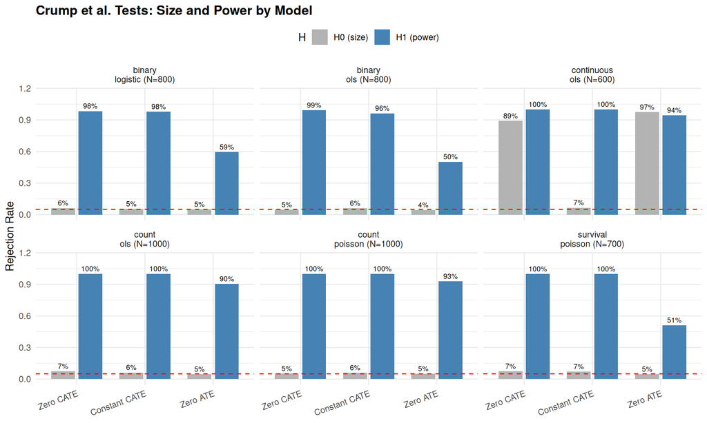

Rejection rates by test, model, and hypothesis.

```r
mc_long <- melt(mc_summary,
  id.vars = c("scenario", "dgm", "N", "regression", "H"),
  measure.vars = c("Zero CATE", "Constant CATE", "Zero ATE"),
  variable.name = "Test", value.name = "Rejection")
mc_long$label <- sprintf("%s\n%s (N=%d)",
  mc_long$dgm, mc_long$regression, mc_long$N)

ggplot(mc_long, aes(x = Test, y = Rejection, fill = H)) +
  geom_col(position = position_dodge(0.8), width = 0.7) +
  geom_hline(yintercept = 0.05, linetype = "dashed",
             colour = "red", linewidth = 0.5) +
  geom_text(aes(label = sprintf("%.0f%%", 100 * Rejection)),
    position = position_dodge(0.8), vjust = -0.5, size = 2.5) +
  facet_wrap(~ label, nrow = 2) +
  scale_fill_manual(
    values = c("H0 (size)" = "grey70", "H1 (power)" = "steelblue")) +
  labs(x = NULL, y = "Rejection Rate",
       title = "Crump et al. Tests: Size and Power by Model") +
  ylim(0, 1.15) +
  theme_minimal(base_size = 11) +
  theme(legend.position = "top",
        axis.text.x = element_text(angle = 20, hjust = 1),
        plot.title = element_text(face = "bold"))
```

# 6 Variance Estimation Diagnostic

## 6.1 Methodology

A well-calibrated variance estimator is essential for valid inference. We evaluate the HC sandwich by comparing two quantities computed across $B$ Monte Carlo replications under $H_0$:

**Empirical variance** (the “truth” from the MC):
$$\widehat{\text{Var}}_{\text{emp}}(\hat\delta_k) =
\frac{1}{B-1} \sum_{b=1}^B
(\hat\delta_k^{(b)} - \bar{\hat\delta}_k)^2$$
where $\hat\delta_k = \hat\xi_{1,k} - \hat\xi_{0,k}$ is the $k$-th component of the coefficient difference, and $\bar{\hat\delta}_k = B^{-1} \sum_b \hat\delta_k^{(b)}$ is its MC mean.

**Mean estimated variance** (the average sandwich output):
$$\bar{\hat{V}}_{kk} = \frac{1}{B} \sum_{b=1}^B \hat{V}_{kk}^{(b)}$$
where $\hat{V}_{kk}^{(b)}$ is the $k$-th diagonal element of the sandwich variance estimate from replicate $b$.

**Variance ratio:**
$$\text{Ratio}_k =
\frac{\bar{\hat{V}}_{kk}}
{\widehat{\text{Var}}_{\text{emp}}(\hat\delta_k)}$$

Interpretation: ratio $\approx 1$ means the sandwich is well-calibrated; ratio $> 1$ means the sandwich is conservative (overestimates variance); ratio $< 1$ means the sandwich is liberal (underestimates variance, inflated Type I error).

## 6.2 Compute Ratios

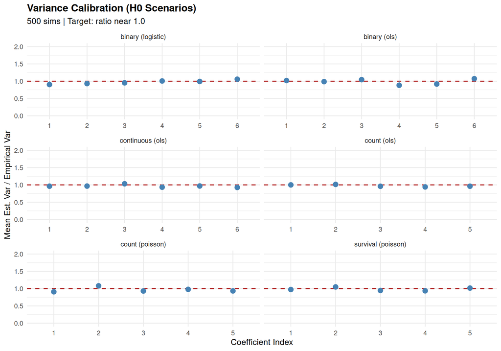

Variance ratio for each coefficient (H0 only).

```r
h0_ids <- mc_summary[grepl("H0", H)]$scenario

var_diag_list <- list()
for (sc in h0_ids) {
  sc_dt <- mc_dt[scenario == sc & !is.na(diff_str) &
                  !is.na(v_diag_str)]
  if (nrow(sc_dt) < 30) next
  diff_mat <- do.call(rbind, lapply(sc_dt$diff_str, function(s)
    as.numeric(strsplit(s, ",")[[1]])))
  var_mat <- do.call(rbind, lapply(sc_dt$v_diag_str, function(s)
    as.numeric(strsplit(s, ",")[[1]])))
  K <- ncol(diff_mat)
  emp_v <- apply(diff_mat, 2, var)
  est_v <- colMeans(var_mat)
  var_diag_list[[sc]] <- data.frame(
    scenario = sc, coef_idx = seq_len(K),
    emp_var = emp_v, est_var = est_v,
    ratio = est_v / emp_v, stringsAsFactors = FALSE)
}

var_diag_df <- do.call(rbind, var_diag_list)

if (nrow(var_diag_df) > 0) {
  var_diag_df <- merge(var_diag_df,
    mc_summary[, .(scenario, dgm, regression)], by = "scenario")
  var_diag_df$label <- sprintf("%s (%s)", var_diag_df$dgm,
                                var_diag_df$regression)

  ggplot(var_diag_df, aes(x = factor(coef_idx), y = ratio)) +
    geom_hline(yintercept = 1.0, linetype = "dashed",
               colour = "firebrick", linewidth = 0.7) +
    geom_point(size = 3, colour = "steelblue") +
    geom_segment(aes(xend = factor(coef_idx), yend = 1.0),
                 colour = "steelblue", linewidth = 0.4) +
    facet_wrap(~ label, scales = "free_x", ncol = 2) +
    labs(x = "Coefficient Index",
         y = "Mean Est. Var / Empirical Var",
         title = "Variance Calibration (H0 Scenarios)",
         subtitle = sprintf("%d sims | Target: ratio near 1.0",
                             nsims)) +
    ylim(0, max(var_diag_df$ratio, 2.0)) +
    theme_minimal(base_size = 12) +
    theme(plot.title = element_text(face = "bold"))
}
```

## 6.3 Variance Summary Table

```r
if (nrow(var_diag_df) > 0) {
  var_summary <- data.table(var_diag_df)[, .(
    K = .N,
    `Mean Emp. Var` = signif(mean(emp_var), 4),
    `Mean Est. Var` = signif(mean(est_var), 4),
    `Mean Ratio` = round(mean(ratio), 3),
    `Median Ratio` = round(median(ratio), 3),
    `Min Ratio` = round(min(ratio), 3),
    `Max Ratio` = round(max(ratio), 3)
  ), by = .(scenario, dgm, regression)]

  gt(var_summary) |>
    tab_header(
      title = md("**Variance Calibration Summary (H0)**"),
      subtitle = paste(
        "Emp. Var = empirical variance of coefficient difference",
        "across sims;",
        "Est. Var = MC average of sandwich diagonal;",
        "Ratio = Est./Emp.")
    ) |>
    tab_spanner(label = "Averages Across K Coefficients",
      columns = c(`Mean Emp. Var`, `Mean Est. Var`)) |>
    tab_spanner(label = "Ratio (Est. / Emp.)",
      columns = c(`Mean Ratio`, `Median Ratio`,
                   `Min Ratio`, `Max Ratio`)) |>
    tab_style(style = cell_fill(color = "#E8F5E9"),
      locations = cells_body(columns = `Mean Ratio`,
        rows = `Mean Ratio` >= 0.85 & `Mean Ratio` <= 1.15)) |>
    tab_style(style = cell_fill(color = "#FFEBEE"),
      locations = cells_body(columns = `Mean Ratio`,
        rows = `Mean Ratio` < 0.85 | `Mean Ratio` > 1.15)) |>
    tab_source_note(
      "Green: mean ratio within 15% of 1.0. Red: outside 15%."
    )
}
```

Variance calibration: empirical vs estimated (averaged across coefficients)

**Variance Calibration Summary (H0)**

Emp. Var = empirical variance of coefficient difference across sims; Est. Var = MC average of sandwich diagonal; Ratio = Est./Emp.

| scenario | dgm | regression | K | Averages Across K Coefficients Mean Emp. Var | Averages Across K Coefficients Mean Est. Var | Ratio (Est. / Emp.) Mean Ratio | Ratio (Est. / Emp.) Median Ratio | Ratio (Est. / Emp.) Min Ratio | Ratio (Est. / Emp.) Max Ratio |
| --- | --- | --- | --- | --- | --- | --- | --- | --- | --- |
| B-H0-logit | binary | logistic | 6 | 0.024440 | 0.023730 | 0.974 | 0.973 | 0.903 | 1.058 |
| B-H0-ols | binary | ols | 6 | 0.001102 | 0.001083 | 0.988 | 1.003 | 0.882 | 1.073 |
| C-H0 | continuous | ols | 6 | 0.015500 | 0.014940 | 0.965 | 0.964 | 0.926 | 1.033 |
| K-H0-ols | count | ols | 5 | 0.003091 | 0.003014 | 0.976 | 0.962 | 0.942 | 1.014 |
| K-H0-pois | count | poisson | 5 | 0.006370 | 0.006126 | 0.966 | 0.933 | 0.908 | 1.080 |
| S-H0-pois | survival | poisson | 5 | 0.007692 | 0.007555 | 0.984 | 0.974 | 0.936 | 1.049 |

Green: mean ratio within 15% of 1.0. Red: outside 15%.

### 6.3.1 Per-Coefficient Detail

```r
if (nrow(var_diag_df) > 0) {
  detail_dt <- data.table(var_diag_df)
  detail_dt$label <- sprintf("%s (%s)", detail_dt$dgm,
                              detail_dt$regression)

  gt(detail_dt[, .(
    `Scenario` = label,
    `Coef k` = coef_idx,
    `Emp. Var` = signif(emp_var, 4),
    `Est. Var` = signif(est_var, 4),
    `Ratio` = round(ratio, 3)
  )]) |>
    tab_header(
      title = md("**Per-Coefficient Variance Detail (H0)**"),
      subtitle = sprintf("%d sims per scenario", nsims)
    ) |>
    tab_style(style = cell_fill(color = "#E8F5E9"),
      locations = cells_body(columns = Ratio,
        rows = Ratio >= 0.85 & Ratio <= 1.15)) |>
    tab_style(style = cell_fill(color = "#FFEBEE"),
      locations = cells_body(columns = Ratio,
        rows = Ratio < 0.85 | Ratio > 1.15))
}
```

Per-coefficient variance calibration (H0 scenarios)

**Per-Coefficient Variance Detail (H0)**

500 sims per scenario

| Scenario | Coef k | Emp. Var | Est. Var | Ratio |
| --- | --- | --- | --- | --- |
| binary (logistic) | 1 | 0.026370 | 0.023820 | 0.903 |
| binary (logistic) | 2 | 0.025520 | 0.023760 | 0.931 |
| binary (logistic) | 3 | 0.024850 | 0.023680 | 0.953 |
| binary (logistic) | 4 | 0.023540 | 0.023700 | 1.007 |
| binary (logistic) | 5 | 0.024320 | 0.024130 | 0.993 |
| binary (logistic) | 6 | 0.022020 | 0.023300 | 1.058 |
| binary (ols) | 1 | 0.001057 | 0.001077 | 1.019 |
| binary (ols) | 2 | 0.001095 | 0.001082 | 0.988 |
| binary (ols) | 3 | 0.001036 | 0.001083 | 1.045 |
| binary (ols) | 4 | 0.001228 | 0.001083 | 0.882 |
| binary (ols) | 5 | 0.001165 | 0.001070 | 0.919 |
| binary (ols) | 6 | 0.001030 | 0.001105 | 1.073 |
| continuous (ols) | 1 | 0.015410 | 0.014830 | 0.963 |
| continuous (ols) | 2 | 0.015540 | 0.015010 | 0.966 |
| continuous (ols) | 3 | 0.014470 | 0.014940 | 1.033 |
| continuous (ols) | 4 | 0.016010 | 0.014950 | 0.934 |
| continuous (ols) | 5 | 0.015450 | 0.014970 | 0.969 |
| continuous (ols) | 6 | 0.016130 | 0.014940 | 0.926 |
| count (ols) | 1 | 0.002965 | 0.002966 | 1.000 |
| count (ols) | 2 | 0.002932 | 0.002974 | 1.014 |
| count (ols) | 3 | 0.003095 | 0.002972 | 0.960 |
| count (ols) | 4 | 0.003160 | 0.002977 | 0.942 |
| count (ols) | 5 | 0.003305 | 0.003178 | 0.962 |
| count (poisson) | 1 | 0.007095 | 0.006444 | 0.908 |
| count (poisson) | 2 | 0.005592 | 0.006041 | 1.080 |
| count (poisson) | 3 | 0.006522 | 0.006069 | 0.931 |
| count (poisson) | 4 | 0.006198 | 0.006065 | 0.978 |
| count (poisson) | 5 | 0.006441 | 0.006010 | 0.933 |
| survival (poisson) | 1 | 0.007780 | 0.007575 | 0.974 |
| survival (poisson) | 2 | 0.007201 | 0.007552 | 1.049 |
| survival (poisson) | 3 | 0.007824 | 0.007398 | 0.946 |
| survival (poisson) | 4 | 0.008203 | 0.007682 | 0.936 |
| survival (poisson) | 5 | 0.007453 | 0.007567 | 1.015 |

## 6.4 Chi-Squared Q-Q Plots

Under $H_0$, the test statistic $Q \sim \chi^2(K)$.

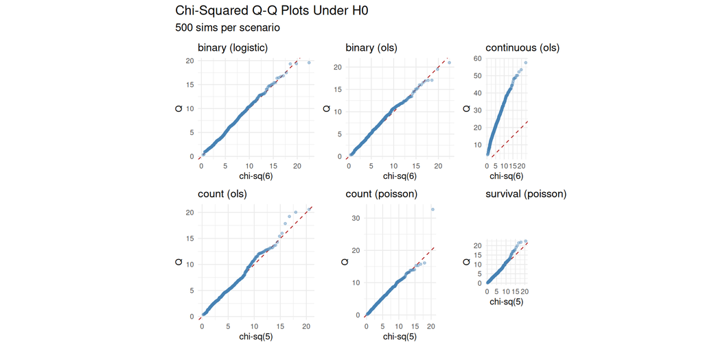

Q-Q: empirical Q vs theoretical chi-squared(K).

```r
h0_dt <- mc_dt[scenario %in% h0_ids & !is.na(Q_zero)]
h0_dt <- merge(h0_dt,
  data.table(mc_scenarios)[, .(id, dgm, regression)],
  by.x = "scenario", by.y = "id")

if (nrow(h0_dt) > 0) {
  h0_dt$label <- sprintf("%s (%s)", h0_dt$dgm, h0_dt$regression)

  qq_list <- lapply(split(h0_dt, h0_dt$label), function(sub) {
    K_val <- sub$K[1]
    n <- nrow(sub)
    ggplot(data.frame(
        theo = qchisq(ppoints(n), df = K_val),
        emp = sort(sub$Q_zero)),
      aes(x = theo, y = emp)) +
      geom_abline(slope = 1, intercept = 0, linetype = "dashed",
                  colour = "firebrick") +
      geom_point(size = 1, alpha = 0.4, colour = "steelblue") +
      labs(x = sprintf("chi-sq(%d)", K_val), y = "Q",
           title = sub$label[1]) +
      coord_equal() +
      theme_minimal(base_size = 9)
  })

  wrap_plots(qq_list, ncol = 3) +
    plot_annotation(
      title = "Chi-Squared Q-Q Plots Under H0",
      subtitle = sprintf("%d sims per scenario", nsims))
}
```

# 7 Real Data: GBSG Breast Cancer Trial

## 7.1 Background

The German Breast Cancer Study Group (GBSG) trial randomized 686 node-positive breast cancer patients to adjuvant **hormonal therapy** (tamoxifen, `hormon = 1`) versus **control** (`hormon = 0`). The endpoint is recurrence-free survival (`rfstime`, days; `status` = 1 for recurrence or death).

This is the same dataset used in the `forestsearch` vignettes and in Leon et al. (2024). The overall ITT hazard ratio is approximately 0.69 (95% CI: 0.54–0.89), suggesting a benefit for hormonal therapy on average.

The question is: **is this benefit uniform, or does it vary across patient subgroups?** The Crump et al. tests can answer this without specifying the subgroups in advance.

## 7.2 Data Preparation

```r
data("gbsg", package = "survival")

df_gbsg <- gbsg
df_gbsg$id <- seq_len(nrow(df_gbsg))
df_gbsg$time_yr <- df_gbsg$rfstime / 365.25
df_gbsg$grade3 <- as.integer(df_gbsg$grade == 3)
df_gbsg$log_fu <- log(df_gbsg$time_yr)

cat("=== GBSG Trial ===\n")
```

```
#> === GBSG Trial ===
```

```r
cat(sprintf("  N: %d\n", nrow(df_gbsg)))
```

```
#>   N: 686
```

```r
cat(sprintf("  Events: %d (%.1f%%)\n",
            sum(df_gbsg$status),
            100 * mean(df_gbsg$status)))
```

```
#>   Events: 299 (43.6%)
```

```r
cat(sprintf("  Hormonal arm: %d | Control: %d\n",
            sum(df_gbsg$hormon == 1),
            sum(df_gbsg$hormon == 0)))
```

```
#>   Hormonal arm: 246 | Control: 440
```

```r
cat(sprintf("  Median follow-up: %.1f years\n",
            median(df_gbsg$time_yr)))
```

```
#>   Median follow-up: 3.0 years
```

## 7.3 ITT Analysis (Benchmark)

```r
library(survival)

fit_itt <- coxph(Surv(rfstime, status) ~ hormon, data = df_gbsg)
hr_itt <- exp(coef(fit_itt)["hormon"])
ci_itt <- exp(confint(fit_itt)["hormon", ])

cat(sprintf("ITT Cox HR: %.3f (95%% CI: %.3f - %.3f)\n",
            hr_itt, ci_itt[1], ci_itt[2]))
```

```
#> ITT Cox HR: 0.695 (95% CI: 0.544 - 0.888)
```

```r
cat(sprintf("  p-value: %.4f\n",
            summary(fit_itt)$coefficients["hormon", "Pr(>|z|)"]))
```

```
#>   p-value: 0.0036
```

## 7.4 Covariate Matrix

The covariates match those used in the `forestsearch` GBSG vignette. All factors are converted to numeric 0/1 indicators.

```r
# Continuous: age, nodes, pgr, er, size
# Binary: meno (menopausal status), grade3
X_gbsg <- cbind(
  age    = df_gbsg$age,
  meno   = df_gbsg$meno,
  size   = df_gbsg$size,
  grade3 = df_gbsg$grade3,
  nodes  = df_gbsg$nodes,
  pgr    = df_gbsg$pgr,
  er     = df_gbsg$er
)

Y_gbsg <- df_gbsg$status
W_gbsg <- df_gbsg$hormon

cat(sprintf("Covariate matrix: %d x %d\n", nrow(X_gbsg), ncol(X_gbsg)))
```

```
#> Covariate matrix: 686 x 7
```

```r
cat("Variables:", paste(colnames(X_gbsg), collapse = ", "), "\n")
```

```
#> Variables: age, meno, size, grade3, nodes, pgr, er
```

## 7.5 OLS Tests

```r
cat("=== OLS (Linear Probability Model) ===\n\n")
```

```
#> === OLS (Linear Probability Model) ===
```

```r
res_gbsg_ols <- test_hte(Y_gbsg, W_gbsg, X_gbsg,
                          regression = "ols")
print(res_gbsg_ols)
```

```
#> === Crump et al. (2008) HTE Tests ===
#>     Covariates: age, meno, size, grade3, nodes, pgr, er
#>
#> 1. Zero Cond. Ave. TE:     chi-sq= 11.86 (df=8) p=0.1576 | z=  0.96 p=0.1673
#> 2. Constant Cond. Ave. TE: chi-sq=  5.16 (df=7) p=0.6402 | z= -0.49 p=0.6883
#> 3. Zero Ave. TE:           chi-sq=  4.59 (df=1) p=0.0322 | z= -2.14 p=0.0322
#>
#> N0=440, N1=246, K=8
```

## 7.6 Logistic Tests

```r
cat("=== Logistic Regression ===\n\n")
```

```
#> === Logistic Regression ===
```

```r
res_gbsg_logit <- test_hte(Y_gbsg, W_gbsg, X_gbsg,
                            regression = "logistic")
print(res_gbsg_logit)
```

```
#> === Crump et al. (2008) HTE Tests ===
#>     Regression: logistic
#>     Covariates: age, meno, size, grade3, nodes, pgr, er
#>
#> 1. Zero Cond. Ave. TE:     chi-sq= 14.19 (df=8) p=0.0769 | z=  1.55 p=0.0608
#> 2. Constant Cond. Ave. TE: chi-sq=  8.46 (df=7) p=0.2936 | z=  0.39 p=0.3480
#> 3. Zero Ave. TE:           chi-sq=  4.59 (df=1) p=0.0322 | z= -2.14 p=0.0322
#>
#> N0=440, N1=246, K=8
```

## 7.7 Poisson + Offset Tests (IRR Scale)

Using the Poisson + offset approach with $\log(\text{follow-up time in years})$ as offset. This tests for HTE on the **incidence rate ratio** scale, matching the `forestsearch` IRR pipeline.

```r
cat("=== Poisson + Offset (IRR Scale) ===\n\n")
```

```
#> === Poisson + Offset (IRR Scale) ===
```

```r
res_gbsg_pois <- test_hte(Y_gbsg, W_gbsg, X_gbsg,
                           regression = "poisson",
                           offset = df_gbsg$log_fu)
print(res_gbsg_pois)
```

```
#> === Crump et al. (2008) HTE Tests ===
#>     Regression: poisson
#>     Covariates: age, meno, size, grade3, nodes, pgr, er
#>
#> 1. Zero Cond. Ave. TE:     chi-sq= 16.18 (df=8) p=0.0399 | z=  2.05 p=0.0204
#> 2. Constant Cond. Ave. TE: chi-sq=  9.23 (df=7) p=0.2366 | z=  0.60 p=0.2757
#> 3. Zero Ave. TE:           chi-sq=  4.59 (df=1) p=0.0322 | z= -2.14 p=0.0322
#>
#> N0=440, N1=246, K=8
```

## 7.8 Covariate Selection Comparison

Following Tables 2 and 4 of Crump et al., we compare all three covariate selection methods for each regression model.

```r
run_gbsg_methods <- function(Y, W, X, reg, off = NULL, label) {
  methods <- c("all", "top_down", "bottom_up")
  rows <- list()
  for (m in methods) {
    t0 <- tryCatch(
      test_zero_cate(Y, W, X, covariate_select = m,
                      regression = reg, offset = off),
      error = function(e) NULL)
    t1 <- tryCatch(
      test_constant_cate(Y, W, X, covariate_select = m,
                          regression = reg, offset = off),
      error = function(e) NULL)
    ate <- mean(Y[W == 1]) - mean(Y[W == 0])
    se <- sqrt(var(Y[W == 1]) / sum(W == 1) +
                var(Y[W == 0]) / sum(W == 0))

    # Extract selected covariate names
    sel_names <- if (!is.null(t0) &&
                      !is.null(t0$covariates_selected)) {
      paste(t0$covariates_selected, collapse = ", ")
    } else {
      paste(colnames(X), collapse = ", ")
    }

    rows[[m]] <- data.frame(
      Model = label, Method = m,
      Selected = sel_names,
      Z_chisq = if (!is.null(t0)) round(t0$chi_sq, 2) else NA,
      Z_dof = if (!is.null(t0)) t0$df else NA,
      Z_pval = if (!is.null(t0)) round(t0$p_value_chi, 3) else NA,
      C_chisq = if (!is.null(t1)) round(t1$chi_sq, 2) else NA,
      C_dof = if (!is.null(t1)) t1$df else NA,
      C_pval = if (!is.null(t1)) round(t1$p_value_chi, 3) else NA,
      A_chisq = round((ate / se)^2, 2),
      A_pval = round(2 * pnorm(abs(ate / se),
                                lower.tail = FALSE), 3),
      stringsAsFactors = FALSE
    )
  }
  do.call(rbind, rows)
}

tab_ols <- run_gbsg_methods(Y_gbsg, W_gbsg, X_gbsg,
  "ols", NULL, "OLS")
tab_log <- run_gbsg_methods(Y_gbsg, W_gbsg, X_gbsg,
  "logistic", NULL, "Logistic")
tab_poi <- run_gbsg_methods(Y_gbsg, W_gbsg, X_gbsg,
  "poisson", df_gbsg$log_fu, "Poisson+offset")
tab_gbsg <- rbind(tab_ols, tab_log, tab_poi)

gt(tab_gbsg) |>
  tab_header(
    title = md("**GBSG Trial: HTE Tests by Model and Covariate Selection**"),
    subtitle = sprintf("N = %d, %d events (%.0f%%), 7 candidate covariates",
      nrow(df_gbsg), sum(df_gbsg$status),
      100 * mean(df_gbsg$status))
  ) |>
  tab_spanner(label = "Zero Cond. Ave. TE",
              columns = c(Z_chisq, Z_dof, Z_pval)) |>
  tab_spanner(label = "Constant Cond. Ave. TE",
              columns = c(C_chisq, C_dof, C_pval)) |>
  tab_spanner(label = "Zero Ave. TE",
              columns = c(A_chisq, A_pval)) |>
  cols_label(
    Model = "Model", Method = "Method", Selected = "Selected Covariates",
    Z_chisq = "chi-sq", Z_dof = "dof", Z_pval = "p-val",
    C_chisq = "chi-sq", C_dof = "dof", C_pval = "p-val",
    A_chisq = "chi-sq", A_pval = "p-val"
  ) |>
  tab_row_group(label = "Poisson + Offset",
                rows = Model == "Poisson+offset") |>
  tab_row_group(label = "Logistic",
                rows = Model == "Logistic") |>
  tab_row_group(label = "OLS",
                rows = Model == "OLS") |>
  tab_style(style = cell_fill(color = "#E8F5E9"),
    locations = cells_body(columns = Z_pval,
      rows = !is.na(Z_pval) & Z_pval < 0.05)) |>
  tab_style(style = cell_fill(color = "#E8F5E9"),
    locations = cells_body(columns = C_pval,
      rows = !is.na(C_pval) & C_pval < 0.05)) |>
  tab_source_note(paste(
    "Green: p < 0.05. 'Selected Covariates' shows which",
    "variables survived the selection procedure.",
    "Selection uses control-group data only (|t| >= 2 threshold)."))
```

GBSG HTE Tests: Three Covariate Selection Methods

**GBSG Trial: HTE Tests by Model and Covariate Selection**

N = 686, 299 events (44%), 7 candidate covariates

| Model | Method | Selected Covariates | Zero Cond. Ave. TE chi-sq | Zero Cond. Ave. TE dof | Zero Cond. Ave. TE p-val | Constant Cond. Ave. TE chi-sq | Constant Cond. Ave. TE dof | Constant Cond. Ave. TE p-val | Zero Ave. TE chi-sq | Zero Ave. TE p-val |
| --- | --- | --- | --- | --- | --- | --- | --- | --- | --- | --- |
| OLS |  |  |  |  |  |  |  |  |  |  |
| OLS | all | age, meno, size, grade3, nodes, pgr, er | 11.86 | 8 | 0.158 | 5.16 | 7 | 0.640 | 4.59 | 0.032 |
| OLS | top_down | nodes, pgr | 7.83 | 3 | 0.050 | 2.49 | 2 | 0.288 | 4.59 | 0.032 |
| OLS | bottom_up | nodes, pgr | 7.83 | 3 | 0.050 | 2.49 | 2 | 0.288 | 4.59 | 0.032 |
| Logistic |  |  |  |  |  |  |  |  |  |  |
| Logistic | all | age, meno, size, grade3, nodes, pgr, er | 14.19 | 8 | 0.077 | 8.46 | 7 | 0.294 | 4.59 | 0.032 |
| Logistic | top_down | nodes, pgr | 10.05 | 3 | 0.018 | 5.12 | 2 | 0.077 | 4.59 | 0.032 |
| Logistic | bottom_up | nodes, pgr | 10.05 | 3 | 0.018 | 5.12 | 2 | 0.077 | 4.59 | 0.032 |
| Poisson + Offset |  |  |  |  |  |  |  |  |  |  |
| Poisson+offset | all | age, meno, size, grade3, nodes, pgr, er | 16.18 | 8 | 0.040 | 9.23 | 7 | 0.237 | 4.59 | 0.032 |
| Poisson+offset | top_down | nodes, pgr | 13.74 | 3 | 0.003 | 7.23 | 2 | 0.027 | 4.59 | 0.032 |
| Poisson+offset | bottom_up | nodes, pgr | 13.74 | 3 | 0.003 | 7.23 | 2 | 0.027 | 4.59 | 0.032 |

Green: p < 0.05. 'Selected Covariates' shows which variables survived the selection procedure. Selection uses control-group data only (|t| >= 2 threshold).

## 7.9 Interpretation

The GBSG results should be compared with the findings from the `forestsearch` GBSG vignette. Key questions:

1. **Zero CATE test**: Does hormonal therapy have a nonzero average effect for ALL covariate-defined subpopulations? The standard ITT test found HR = 0.695 with $p$ = 0.0036. The Zero CATE test asks a stronger question.
2. **Constant CATE test**: Is the treatment effect HETEROGENEOUS? If this test rejects, it provides formal justification for running `forestsearch()` to identify which subgroups benefit more or less from hormonal therapy.
3. **Robustness across models**: Do the OLS, logistic, and Poisson + offset approaches give consistent conclusions? Consistency across models strengthens the evidence.
4. **Robustness across covariate selection**: Do the results change materially between all-covariates, top-down, and bottom-up? The “Selected Covariates” column reveals which variables the selection procedure retained. Stability across methods (as Crump et al. found in their GAIN and WIN analyses) supports the reliability of the conclusions.
5. **Which covariates drive the heterogeneity?** The top-down and bottom-up methods identify which covariates are most predictive of the outcome in the control group (and thus candidates for effect modification). If the same covariates appear in both selection methods, this provides converging evidence about the dimensions along which the treatment effect varies. Compare these with the covariates that `forestsearch` identifies as defining the harm subgroup.

# 8 Choosing the Basis and ForestSearch Integration

## 8.1 The Theory-Practice Gap in Basis Selection

The asymptotic theory (Assumption 3.3) requires $K$ to grow with $N$ at rate $K = C \cdot N^\nu$ for $d/(2s+2d) < \nu < 2/13$. This ensures the series approximation becomes arbitrarily flexible while the normal approximation remains valid. The rate $\nu < 2/13 \approx 0.154$ is quite slow — for $N = 1000$, even $\nu = 0.15$ gives $K \approx 3$–4 terms.

In practice (Section IV, Tables 2 and 4), the paper uses a **fixed** basis of linear terms with substantive covariate selection. In the GAIN analysis: 7 demographics + age$^2$ + 10 quarterly earnings + 10 zero-earnings indicators = 28 covariates, giving $K = 29$. The top-down and bottom-up methods then reduce this to $K = 2$–8 depending on the site.

The paper acknowledges this gap explicitly (p. 395): using $K$ larger than necessary “combines the test of $\xi_{K_0}$ being zero with tests of additional parameters … being equal to zero. The latter are, in fact, zero under the parametric model, and, therefore, this addition lowers the power.”

The practical implication: **including too many irrelevant covariates dilutes power**, while including too few may miss the source of heterogeneity. The covariate selection methods address this by focusing on covariates that are predictive of the outcome (in the control group), which is a reasonable proxy for covariates that might modify the treatment effect.

## 8.2 What the Covariate Selection Methods Do

Each method operates on **control-group data only**, then applies the same specification to the treatment group. This avoids using treatment information in the model selection step.

**All covariates** (`covariate_select = "all"`): Uses every column of $X$ as a linear term. For the GBSG analysis with 7 covariates, this gives $K = 8$ (intercept + 7 slopes). This is the most powerful approach when all covariates are relevant, but loses power if many are noise.

**Bottom-up** (`"bottom_up"`): Starting from the intercept only, sequentially adds the covariate with the largest $|t|$-statistic until no remaining covariate has $|t| \ge 2$. This builds up a parsimonious model, which may differ from the top-down result due to collinearity among covariates.

## 8.3 Screening-Informed Basis Selection

A natural extension is to use **ForestSearch’s own screening step** to inform the Crump test basis. The idea:

1. ForestSearch screens candidate subgroups and identifies $m$ candidates that meet the screening threshold (e.g., $m = 10$ candidates based on $k = 3$ underlying covariates: age, pgr, meno).
2. Extract the $k$ unique covariates from these candidates.
3. Run the Crump test with $X$ = these $k$ covariates, giving $K = k + 1$ basis terms.

This approach has several attractive properties:

- **Data-driven but focused**: The screening step has already identified which covariates carry treatment-effect information. The Crump test then formally evaluates whether this apparent heterogeneity is statistically significant.
- **Complementary to the consistency criterion**: ForestSearch’s consistency evaluation asks whether the *same subgroup* replicates across random splits. The Crump test asks whether *any form of heterogeneity* exists on the identified dimensions. A subgroup might fail the consistency criterion (too noisy to replicate reliably) while the Crump test rejects (there IS heterogeneity on these covariates, even if the exact subgroup boundary is uncertain).
- **Natural integration point**: The screened covariates are available from `fs_result$confounders.evaluated` after GRF/LASSO selection, or from the candidate subgroup definitions after the search step.

### 8.3.1 Statistical Considerations

Using forestsearch-selected covariates creates a **data-dependent basis**, which is not directly covered by the original asymptotic theory. However, several factors mitigate the concern:

1. The **selection mechanism differs** from the test: GRF variable importance selects covariates based on prediction accuracy for the CATE, while the Crump test evaluates coefficient equality across treatment arms. These are related but not identical criteria.
2. ForestSearch screening uses **split-halves**, while the Crump test uses the **full sample**. The data used for selection is partially non-overlapping with the data used for testing.
3. The **direction of bias** from covariate selection is toward rejection (covariates were selected because they appeared relevant). This means the screening-informed test may have **inflated size** under $H_0$. The empirical size should be evaluated via simulation.
4. A **conservative interpretation**: If the screening-informed Crump test does NOT reject, that is strong evidence against HTE on these dimensions, since the test was given every advantage (covariates pre-selected to show apparent HTE). If it DOES reject, the result should be interpreted with the caveat that the covariates were data-selected.

### 8.3.2 Implementation

The `test_hte_from_forestsearch()` function extracts covariates from a forestsearch result and runs the Crump tests:

```
# After running forestsearch
fs <- forestsearch(df.analysis, ...)

# Screening-informed HTE test
hte_fs <- test_hte_from_forestsearch(
  fs_result = fs,
  df = df.analysis,
  outcome.name = "status",
  treat.name = "hormon",
  regression = "poisson",
  offset = log(df.analysis$time_yr)
)

# The result includes:
# - hte_fs$hte_test:         test results
# - hte_fs$covariates_used:  which covariates were selected
# - hte_fs$n_covariates:     K - 1
# - hte_fs$source:           how covariates were selected
```

### 8.3.3 Integration Within ForestSearch

There are two natural integration points:

**Option A: Post-hoc diagnostic** (recommended for v0.2.0). After forestsearch completes, the user calls `test_hte_from_forestsearch()` on the result. This is simple, non-invasive, and allows the user to choose the regression model. The result can be added to the forestsearch output as:

```
fs$hte_diagnostic <- test_hte_from_forestsearch(fs, ...)
```

**Option B: Internal integration** (future). Add the Crump test as an automatic step within `forestsearch()`, reporting the $p$-value alongside the consistency metric. This would require:

- Adding `regression` and `offset` parameters to `forestsearch()` (or inferring them from `outcome_type` and `effect_measure`)
- Running the test after the screening step but before or after consistency evaluation
- Including the test results in the return object

Option B provides a richer output but adds complexity. Option A is the pragmatic first step.

## 8.4 Demonstration: GBSG with ForestSearch-Selected Covariates

```r
# If forestsearch has been run on the GBSG data and the result
# is available, we can demonstrate the integration:
if (exists("fs") && !is.null(fs$confounders.evaluated)) {
  cat("=== ForestSearch-Informed HTE Test ===\n\n")

  hte_fs <- test_hte_from_forestsearch(
    fs_result = fs,
    df = df_gbsg,
    outcome.name = "status",
    treat.name = "hormon",
    regression = "poisson",
    offset = df_gbsg$log_fu
  )

  cat("Covariates used:", paste(hte_fs$covariates_used,
                                 collapse = ", "), "\n")
  cat("Source:", hte_fs$source, "\n")
  cat("K:", hte_fs$n_covariates + 1, "\n\n")
  print(hte_fs$hte_test)
} else {
  cat("ForestSearch result not available in this session.\n")
  cat("To demonstrate, run forestsearch() on the GBSG data first,\n")
  cat("then call test_hte_from_forestsearch() on the result.\n\n")

  # Simulate what the output would look like using the
  # covariates that forestsearch typically selects for GBSG
  # (from the forestsearch vignette: er, meno, pgr, nodes, age)
  cat("--- Simulated integration using typical FS covariates ---\n")
  cat("Covariates: er, meno (from forestsearch screening)\n\n")

  X_fs <- cbind(er = df_gbsg$er, meno = df_gbsg$meno)
  cat("OLS:\n")
  print(test_hte(Y_gbsg, W_gbsg, X_fs, regression = "ols"))

  cat("\nPoisson + offset:\n")
  print(test_hte(Y_gbsg, W_gbsg, X_fs, regression = "poisson",
                  offset = df_gbsg$log_fu))
}
```

```
#> ForestSearch result not available in this session.
#> To demonstrate, run forestsearch() on the GBSG data first,
#> then call test_hte_from_forestsearch() on the result.
#>
#> --- Simulated integration using typical FS covariates ---
#> Covariates: er, meno (from forestsearch screening)
#>
#> OLS:
#> === Crump et al. (2008) HTE Tests ===
#>     Covariates: er, meno
#>
#> 1. Zero Cond. Ave. TE:     chi-sq=  7.01 (df=3) p=0.0717 | z=  1.64 p=0.0510
#> 2. Constant Cond. Ave. TE: chi-sq=  1.25 (df=2) p=0.5356 | z= -0.38 p=0.6464
#> 3. Zero Ave. TE:           chi-sq=  4.59 (df=1) p=0.0322 | z= -2.14 p=0.0322
#>
#> N0=440, N1=246, K=3
#>
#> Poisson + offset:
#> === Crump et al. (2008) HTE Tests ===
#>     Regression: poisson
#>     Covariates: er, meno
#>
#> 1. Zero Cond. Ave. TE:     chi-sq=  9.74 (df=3) p=0.0209 | z=  2.75 p=0.0030
#> 2. Constant Cond. Ave. TE: chi-sq=  0.54 (df=2) p=0.7620 | z= -0.73 p=0.7667
#> 3. Zero Ave. TE:           chi-sq=  4.59 (df=1) p=0.0322 | z= -2.14 p=0.0322
#>
#> N0=440, N1=246, K=3
```

# 9 Summary

## 9.1 Results by Regression Model

- **OLS** (original paper): Works for all outcome types because the HC sandwich handles heteroskedasticity automatically. For binary $Y$, this is a linear probability model — it estimates risk differences, and the sandwich captures the $p(x)(1-p(x))$ variance without requiring specification. Provides proper size control and good power across all DGMs tested.
- **Logistic**: The proper link function for binary outcomes. Tests on the **log-odds** scale rather than the risk-difference scale. May have slightly higher power than OLS when the DGM has effects on the log-OR scale, because the model specification better matches the true data-generating process.
- **Poisson + offset**: Accommodates survival data (event indicator
  - log follow-up as offset) and count data with differential exposure. The coefficients estimate **log event rates**, which directly correspond to the IRR pipeline in `forestsearch`. This enables formal HTE testing on the same scale that `forestsearch` uses for subgroup identification.

## 9.2 Key Diagnostic: The Variance Ratio

The variance ratio $\bar{\hat{V}}_{kk} / \widehat{\text{Var}}_{\text{emp}}(\hat\delta_k)$ is the central calibration diagnostic:

- **Ratio $\approx$ 1.0**: The sandwich variance estimator is well-calibrated. The asymptotic approximation is adequate at the given sample size, and the $\chi^2$ reference distribution is appropriate for computing $p$-values.
- **Ratio $> 1$**: The sandwich **overestimates** the variance. The test is conservative (actual size $<$ nominal level). The $\chi^2$ Q-Q plot will show the empirical quantiles falling below the diagonal.
- **Ratio $< 1$**: The sandwich **underestimates** the variance. The test is liberal (actual size $>$ nominal level). This is more concerning and may require larger $N$ or a bias-corrected variance estimator (HC1, HC2, or HC3).

## 9.3 Interpreting the Continuous H0 Results

Under the continuous H0 DGM ($\tau(x) = -0.5$ for all $x$), the expected behavior is:

| Test | Expected | Reason |
| --- | --- | --- |
| Zero CATE | **Reject** (high power) | $\tau(x) = -0.5 \ne 0$ |
| Constant CATE | **Not reject** (~5%) | $\tau(x)$ IS constant |
| Zero ATE | **Reject** (high power) | $E[\tau(X)] = -0.5 \ne 0$ |

This confirms that the “null” in our simulation study means “no HTE” (uniform treatment effect), not “no treatment effect.” The Constant CATE test correctly identifies the absence of heterogeneity even when the overall effect is large.

## 9.4 Connection to ForestSearch

The **Constant CATE test** is the pre-screening diagnostic for `forestsearch()`. If it rejects at the 5% level, there is formal evidence of treatment effect heterogeneity, and subgroup identification is scientifically motivated. If it does not reject, any subgroup found by `forestsearch()` should be interpreted cautiously — the apparent heterogeneity may be a chance finding.

These tests are computationally trivial (OLS or GLM fit + sandwich variance, no bootstrap or simulation) and can be run as a **first step** before the more expensive `forestsearch()` procedure.

# 10 References

- Crump, R.K., Hotz, V.J., Imbens, G.W., Mitnik, O.A. (2008). Nonparametric Tests for Treatment Effect Heterogeneity. *Review of Economics and Statistics*, 90(3), 389–405.
- Leon, L.F., et al. (2024). Exploratory Subgroup Identification. *Statistics in Medicine*, 43, 4253–4275. doi:10.1002/sim.10163

# 11 Timing and Session Info

```r
timings$total <- (proc.time() - t_vignette_start)["elapsed"]
gt(data.frame(
  Stage = c("Monte Carlo", "Total"),
  Seconds = c(timings$mc, timings$total),
  Minutes = c(timings$mc, timings$total) / 60
)) |>
  tab_header(
    title = "Timing",
    subtitle = sprintf("%d sims x %d scenarios | %d workers",
      nsims, nrow(mc_scenarios), n_workers)
  ) |>
  fmt_number(columns = c(Seconds, Minutes), decimals = 1)
```

Timing

500 sims x 12 scenarios | 120 workers

| Stage | Seconds | Minutes |
| --- | --- | --- |
| Monte Carlo | 6.3 | 0.1 |
| Total | 11.8 | 0.2 |

```r
plan(sequential)
```